# Google User Behaviour Study

FrontPage Data and Backlinko

2020-08-13

# 0. Introduction

The current lack of data from Google about the behavior of users has been the greatest frustration for SEOs. Although some previous studies have tried to analyze user behavior on Google, most of them are outdated as SERP features have changed over the past years.

This study intends to fill the gap and shed some timely and novel insights on how users interact with Google’s SERP features.

In this study, we address the following research questions:

1. What percentage of users used the search suggestion?
2. What is the average time to first click?
3. What percentage of users scroll to the bottom of the first page?
4. What percentage of users change their search query?
5. What percentage of users bounces back to the search results and chooses a different result? (i.e.pogo-sticking)?
6. How many pages do users visit on average?
7. What percent of clicks go to organic search results?
8. What percent of clicks go to Google Adwords or paid listings?
9. What percent of clicks go to video results?
10. What percent of clicks go to google maps listings?
11. What percent of clicks go to shopping results?
12. What percent of clicks go to “people also ask” box?
13. What percent of clicks go to page 2nd+ Google page?
14. How long is the average Google search session? (after entering a search query and hitting enter)
15. What´s the average number of clicks in a Google Search Session?
16. Do we see any relationship between key variables in a Google Search?

# 0.1 Methodology

**Step 1 Survey Design**: We provided the survey respondents with a set of Google search queries. In order to provide a broad set of search queries, we settled for the following ones:

1. Commercial_1_pyhsical: find a car phone holder (assumption: Google shopping results)
2. Commercial_2_service: find a credit card (assumptions: affiliate articles)
3. Local: find a car accident lawyer (assumptions: ads)
4. Informational_1: find how to cut your own hair (assumptions: videos)
5. Informational_2: find how to treat back pain (assumptions: in-depth articles)
6. Transactional: find supplements that may help with lower back pain
7. Commercial_3_service: buy groceries online in your local area

You can find the survey questions here: [Link](https://docs.google.com/document/d/1HNIJ_mWbREtgWrVgm5EvbhTjxL8he_Ix-HnHVBuuKHQ/edit?usp=sharing)

**Step 2 Survey Tools and Screen Recording**: Secondly, we decided to screen record survey participants to derive useful data points for our study. Our survey tool of choice was surveygizmo.com, as it nicely integrated with the screen recording software addpipe.com. US-Participants for the study were recruited on Mechnical Turk. The survey instructions can be found [here](https://docs.google.com/document/d/1HNIJ_mWbREtgWrVgm5EvbhTjxL8he_Ix-HnHVBuuKHQ/edit#bookmark=id.w8e7mmaqaluj) and a sample screen recording video can be watched [here](https://us1-addpipe.s3-us-west-1.amazonaws.com/4f295537e6741ceea82cfdd0c5caebf9/xOpH5an8WIW30XkcyS6NsTqK5nBPhaeD.mp4).

**Step 3 Data Annotation**: Thirdly, to consider only valid responses for the data annotation task, we reviewed each video individually to check whether instructions were followed properly. We then annotated the video data and entered each data point into a spread sheet. We collected data on 259 videos with a total length of 281 minutes.

# 1. Use of suggested searches

We measure for each question what percentage of users used the search suggestion. We find that users use them between 18% and 31% of the time, globally 23% of the time on average.

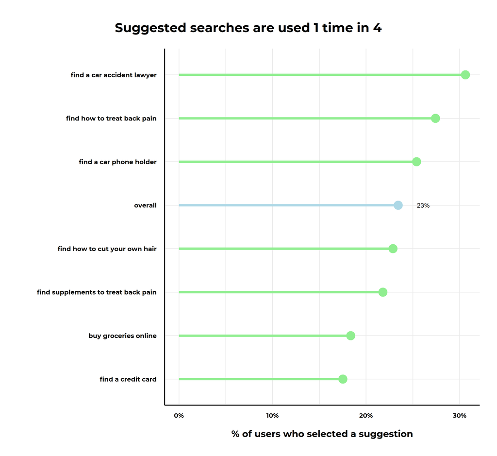

# 2. Time to first click

Using the video timestamps we can assess the time when users click for the first time. We find that the on average a user clicks first after 15 seconds and that half of the users click between 5 seconds and 17 seconds after getting on the page.

The average time to first click, when we consider questions independently, varies from 10 to 25 seconds.

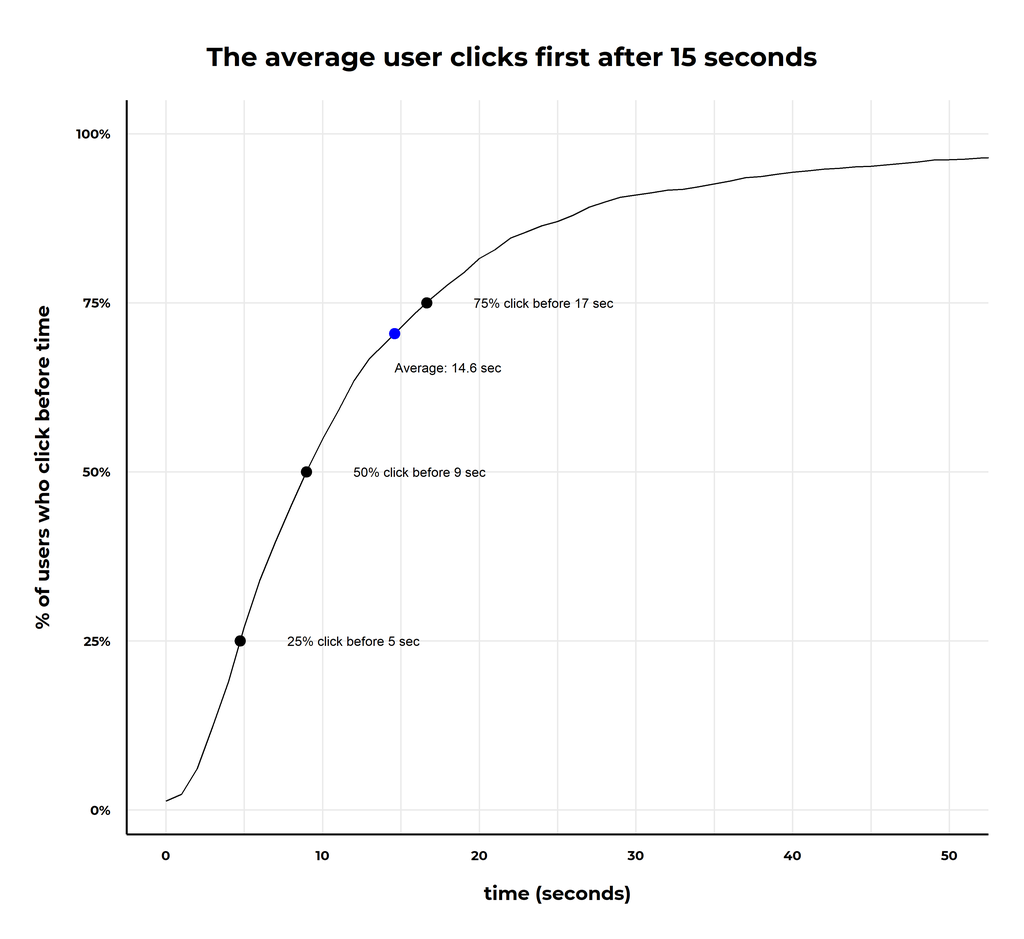

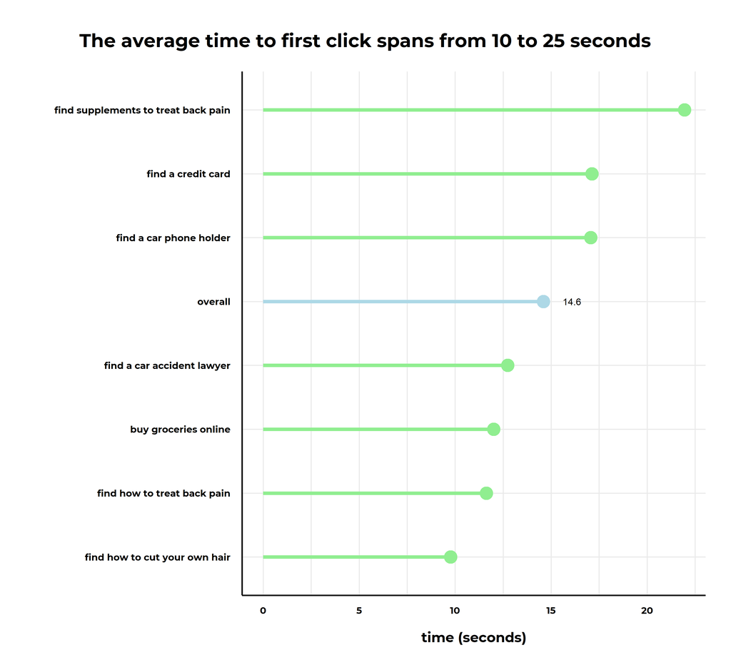

# 3. Scrolling to the bottom of the search page

On average 9% of users reach the bottom of the page, as we can expect this varies however significantly depending on the query, the most specific queries leading to higher percentage. We find that to find a car phone holder, as little as 3% of the users reach the bottom, while 17% (almost 6 times more) reach it when searching for supplements to treat back pain.

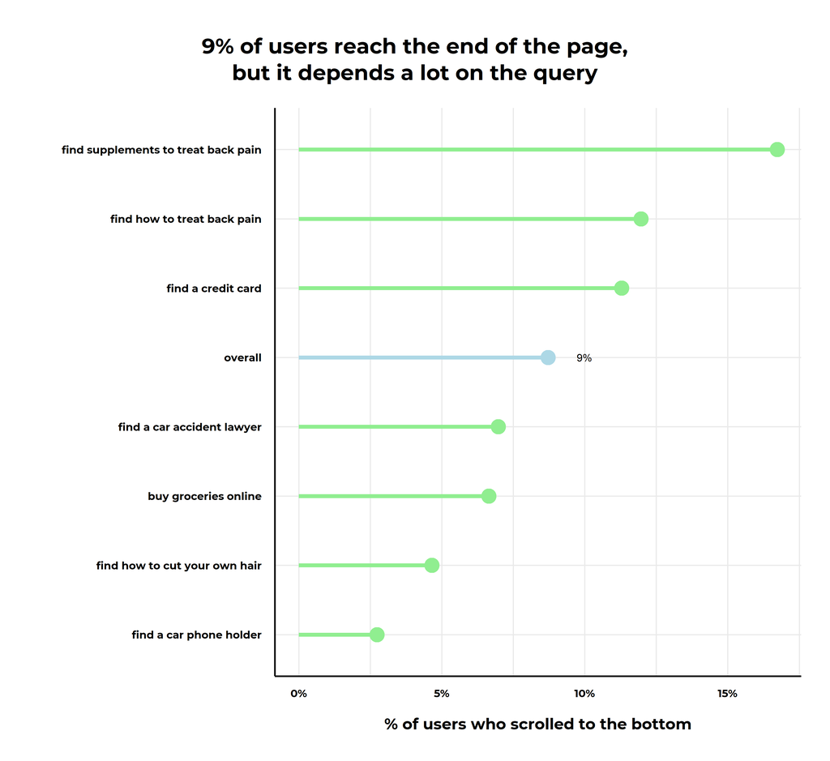

# 4. Modifications of the search query

In the majority of cases (85%), we find that users don’t change their search query at all. 11% change it once and only 4% change it 2 times or more.

Modifying one’s query or not depends a lot on the nature of the search. Our data shows that the percentage of users who change their query can go from under 5% to more than 35% when trying to find supplements for back pain.

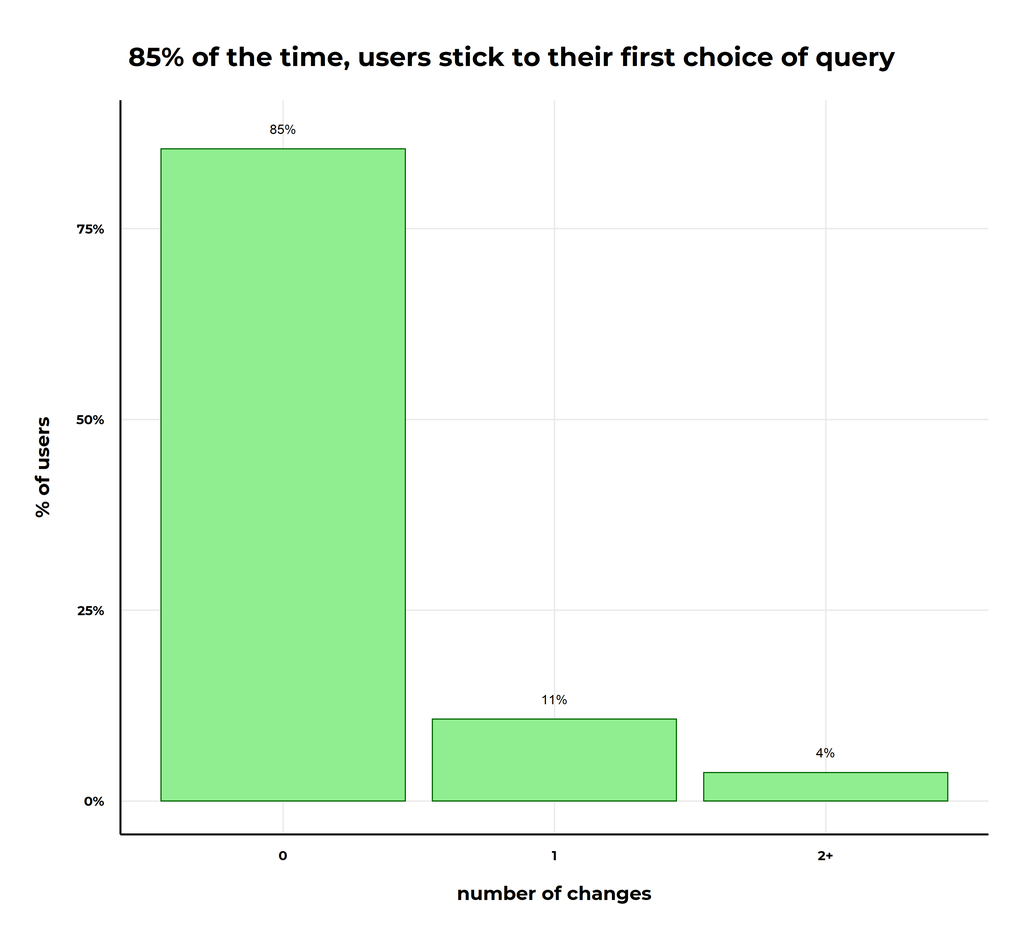

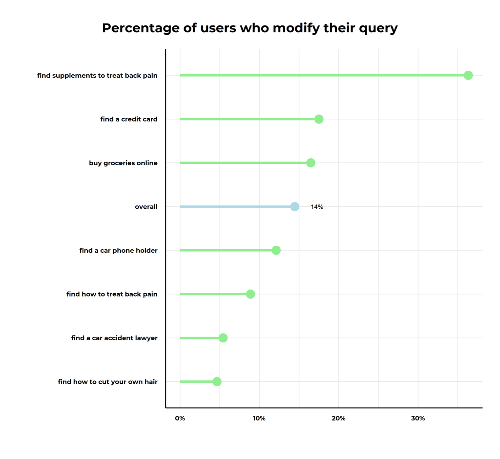

# 5. Bounce

We measure how many times searchers clicks a result, then bounces back to the search results page and chooses a different result. We find that overall the bounce rate is small, 83% never bounce while only 5% bounce more than once.

Depending on the question, this percentage of users who bounce at least once varies in the of 10% to 30%.

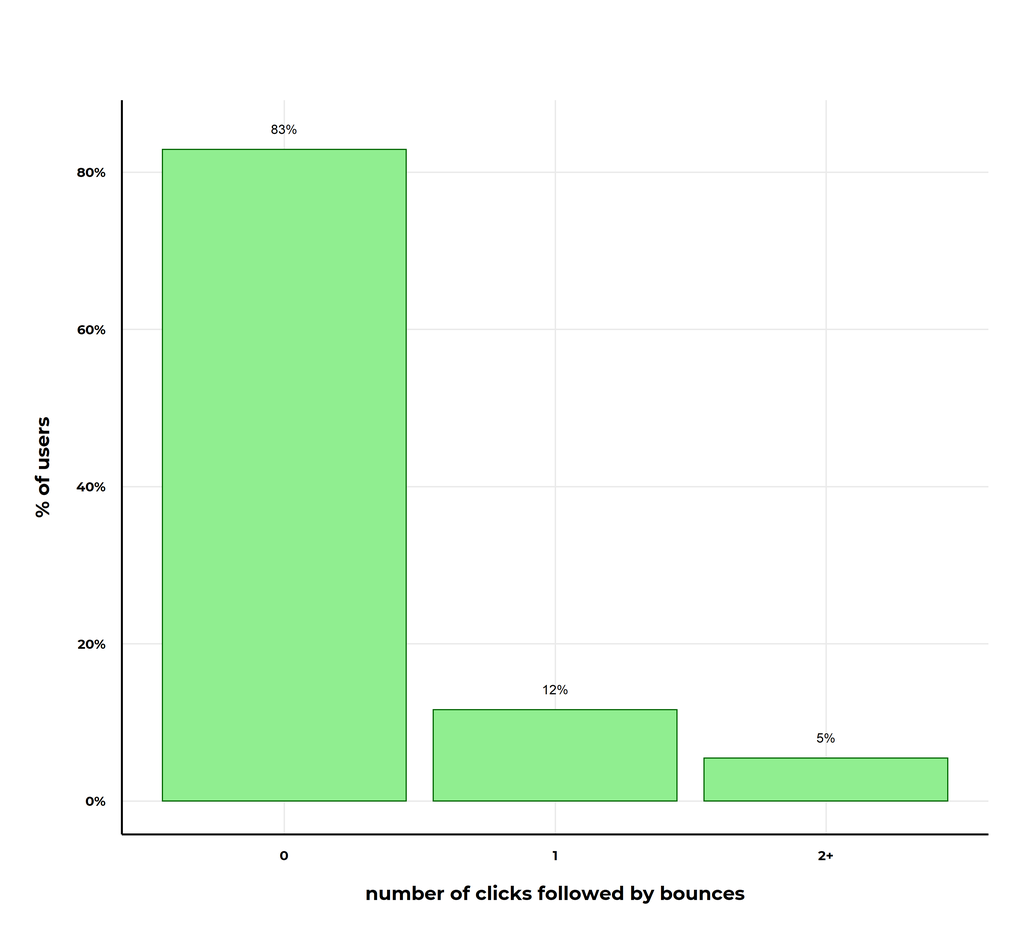

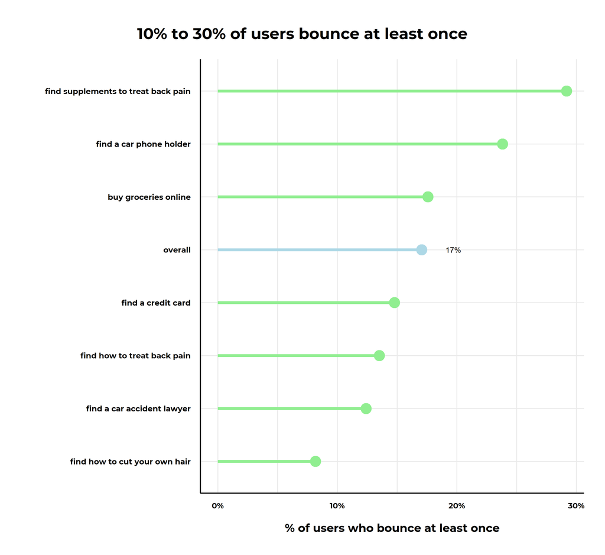

# 6. Number of pages visited

We find that most users visit only one page, but for some specific queries the average can go above 2.

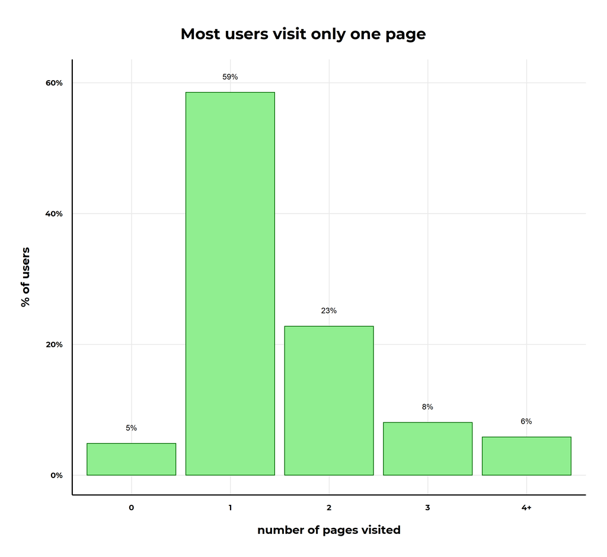

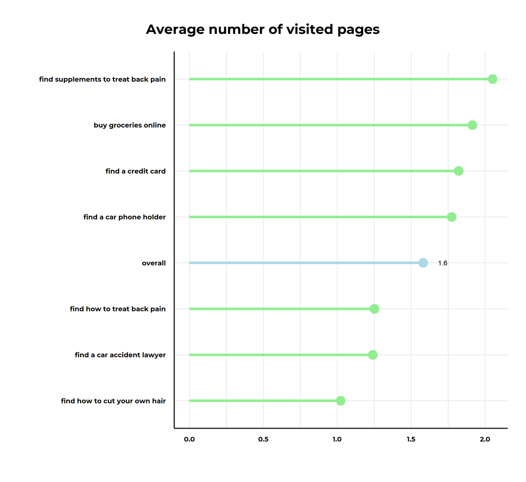

# 7. Clicks on organic search results

We find that most users click on organic search results at least once. However two questions stand out, few users click on organic search results when looking for a car accident lawyer or how to cut one’s hair.

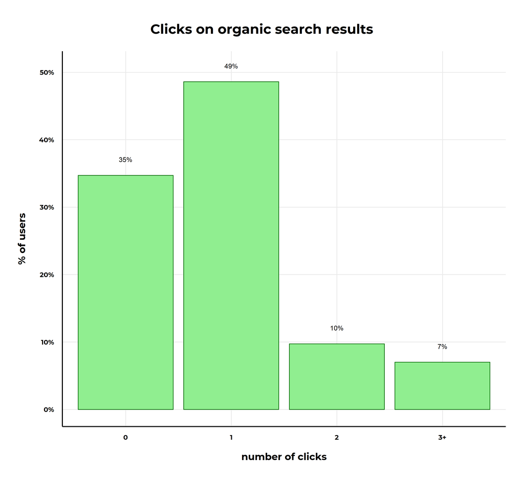

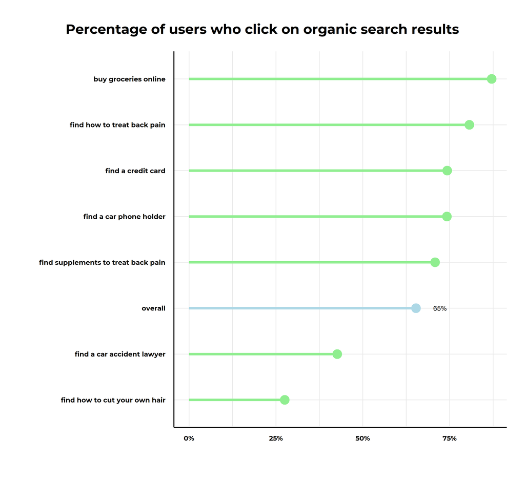

# 8. Clicks on Google AdWords or paid listings

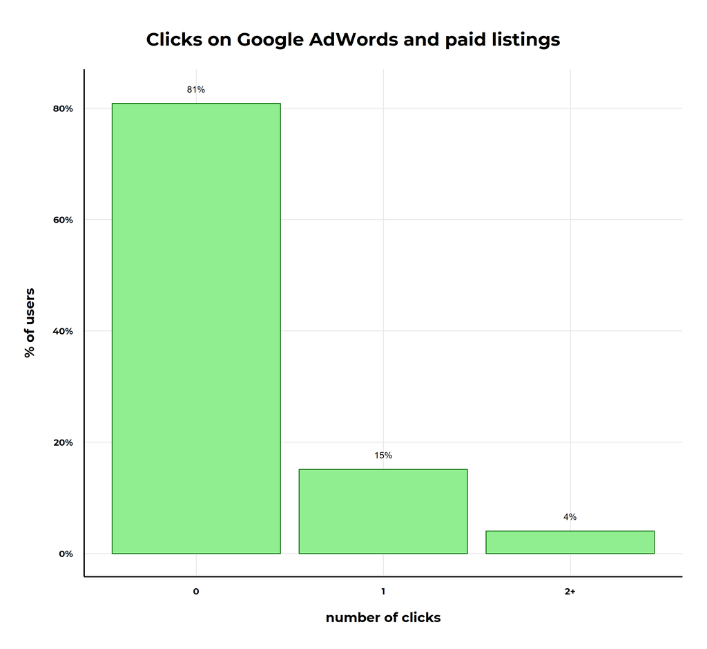

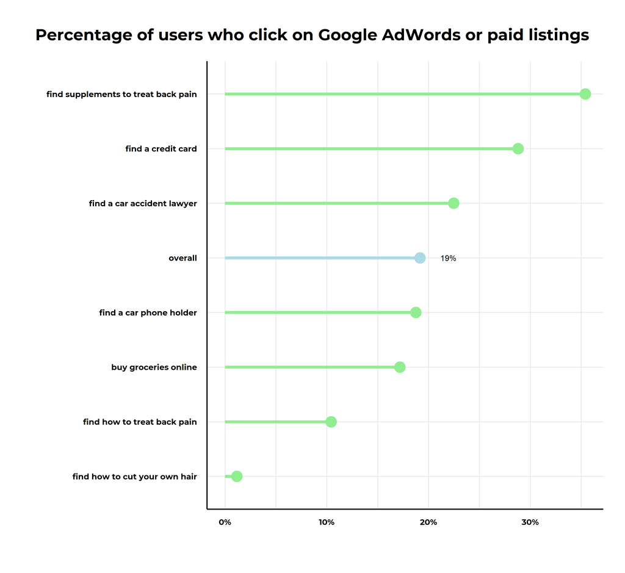

# 9. Clicks on video results

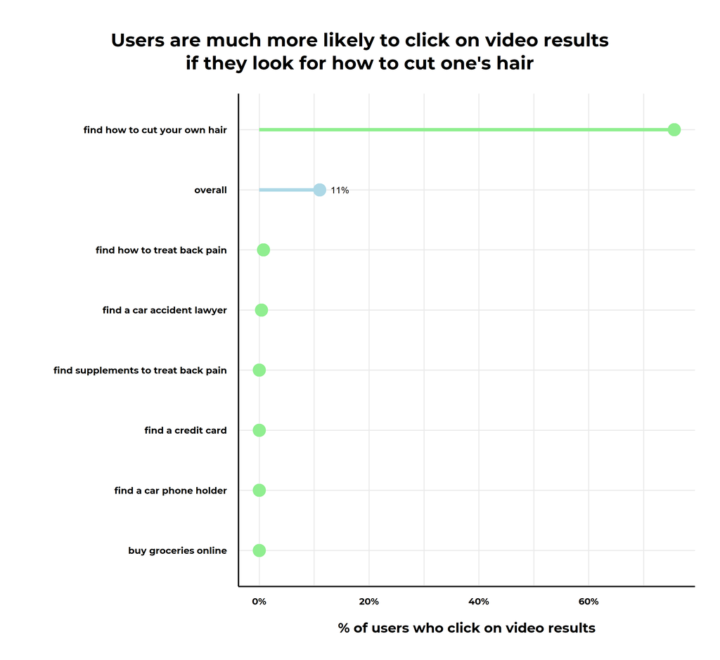

# 10. Clicks on Google Maps or local listings

We find that users click on Google Maps or local listings 40% of the time when the query is about finding a car accident lawyer, and very few times otherwise.

Additionally, our data indicates that when the user clicked on Google Maps or local listings, their chance of clicking on one of the 3 first listings is 97%.

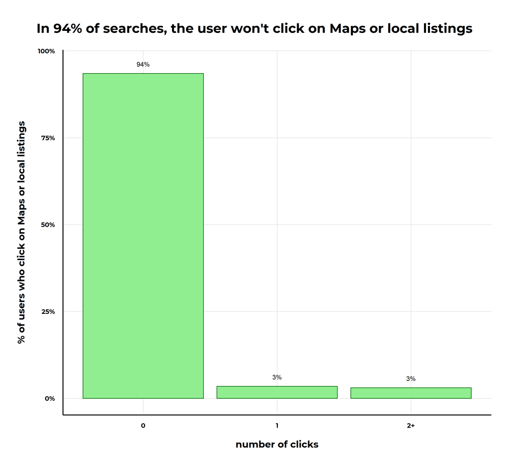

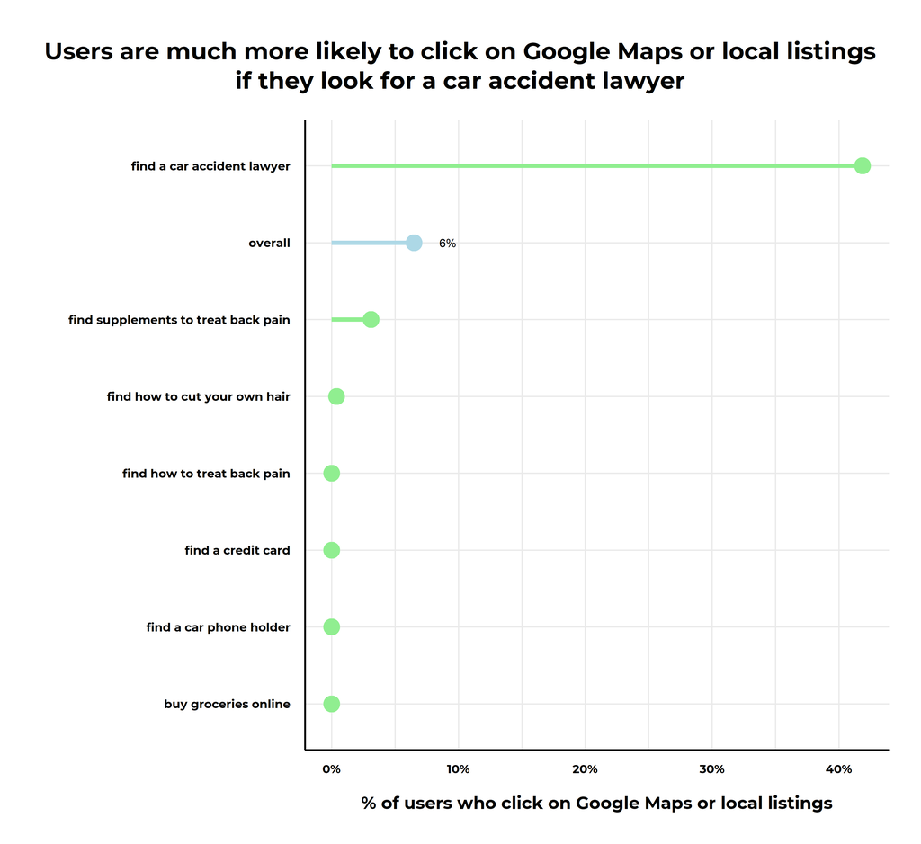

# 11. Clicks on Google Shopping results

[figure not shown]

# 12. Clicks “people also ask” box

Almost 15% of users click the “people also ask” box when the question is about finding supplements forback pain. For other queries this varies from 0% to 3%.

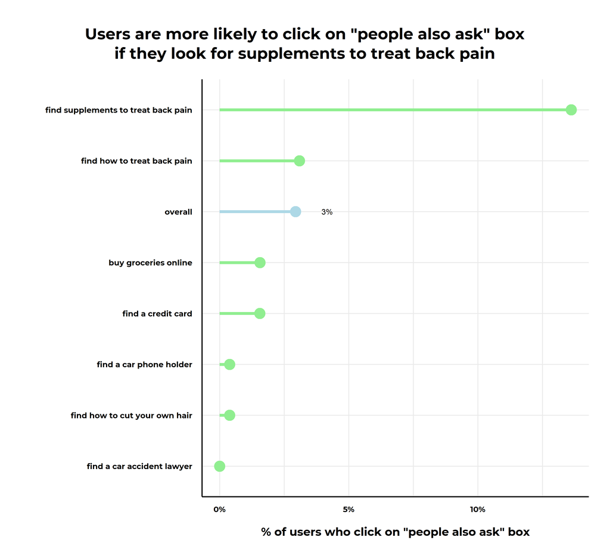

# 13. Clicks to 2nd+ Google page

We find that very few users (0.5%) click on the second google search page or further. Looking at the distinct questions, we see that users looking for supplemenetation to treat back pain are the most likely to reach the second page or further (1.5%).

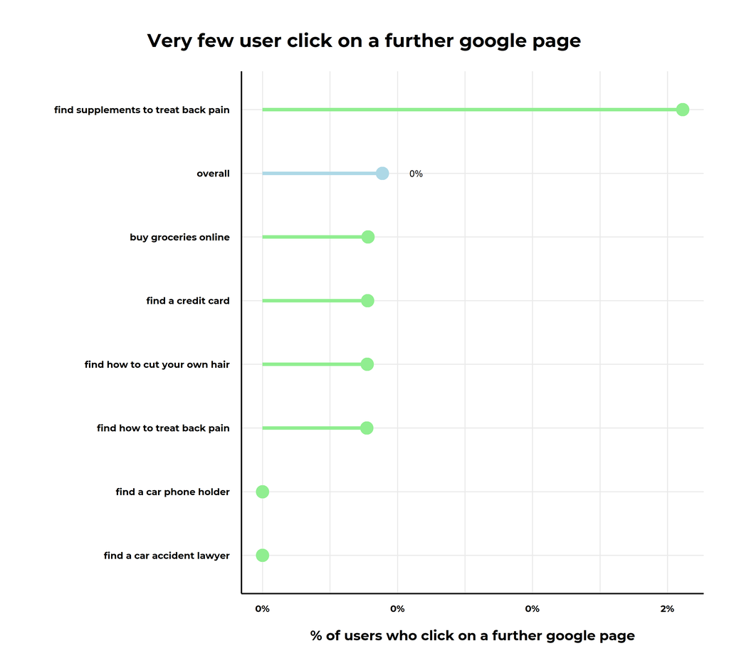

# 14. Time taken to complete the search

The average search is computed in 76 seconds, and we find that half of the searches are completed in 30 seconds to 90 seconds.

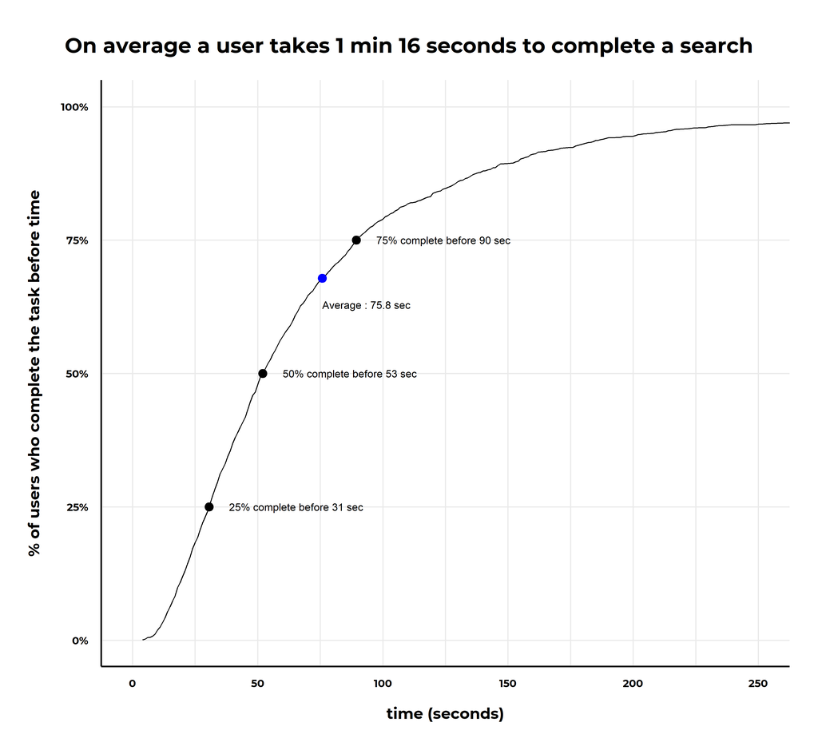

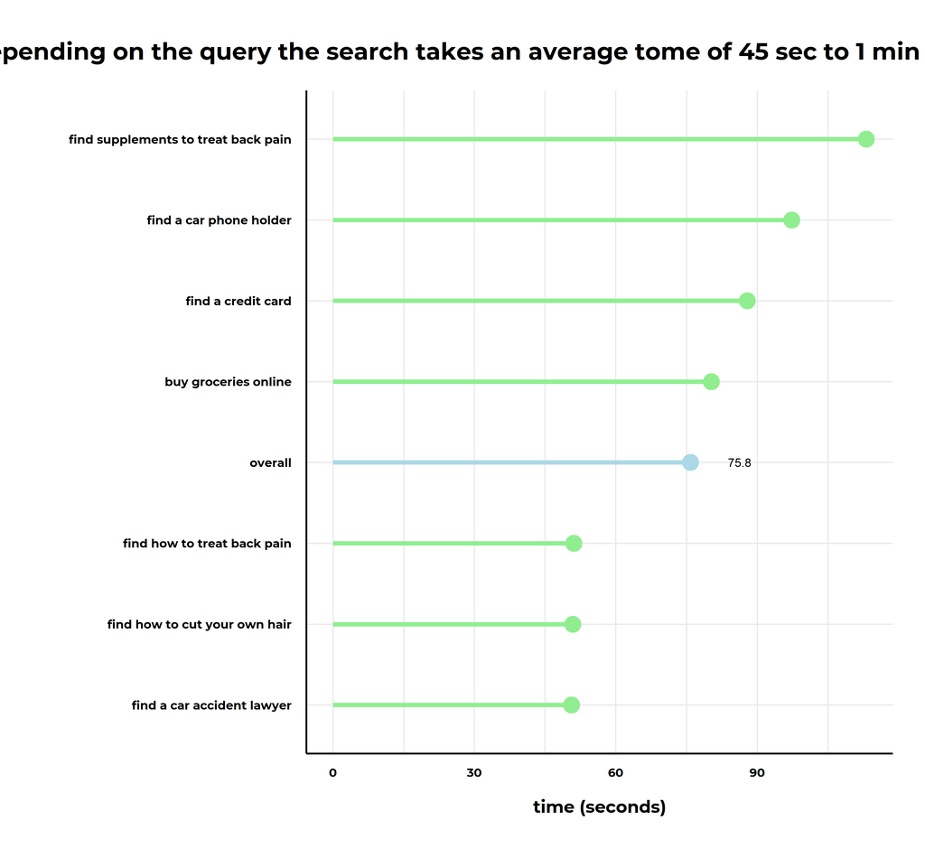

# 15. Total Clicks

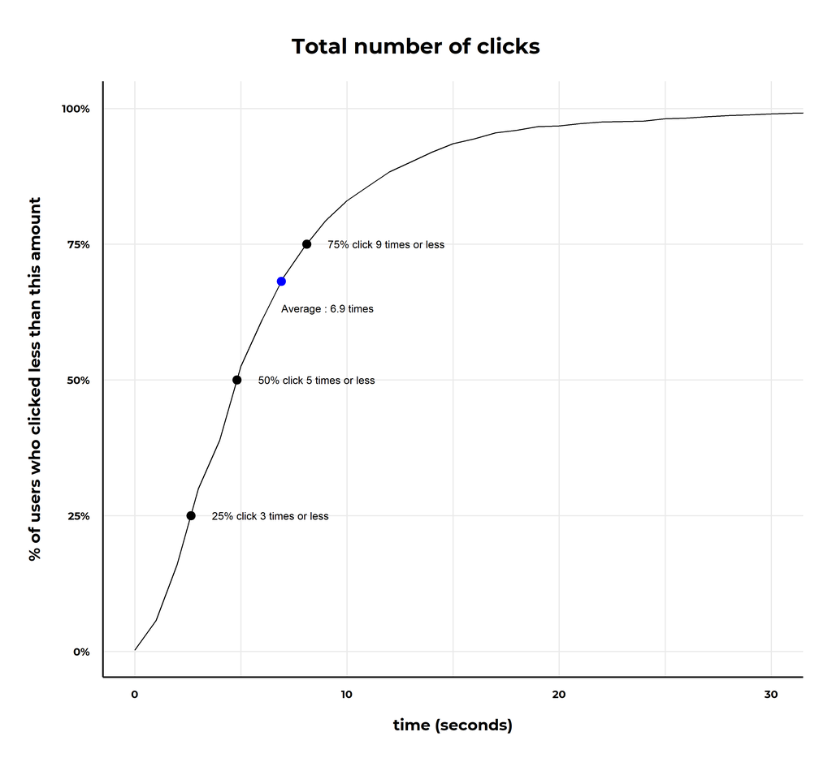

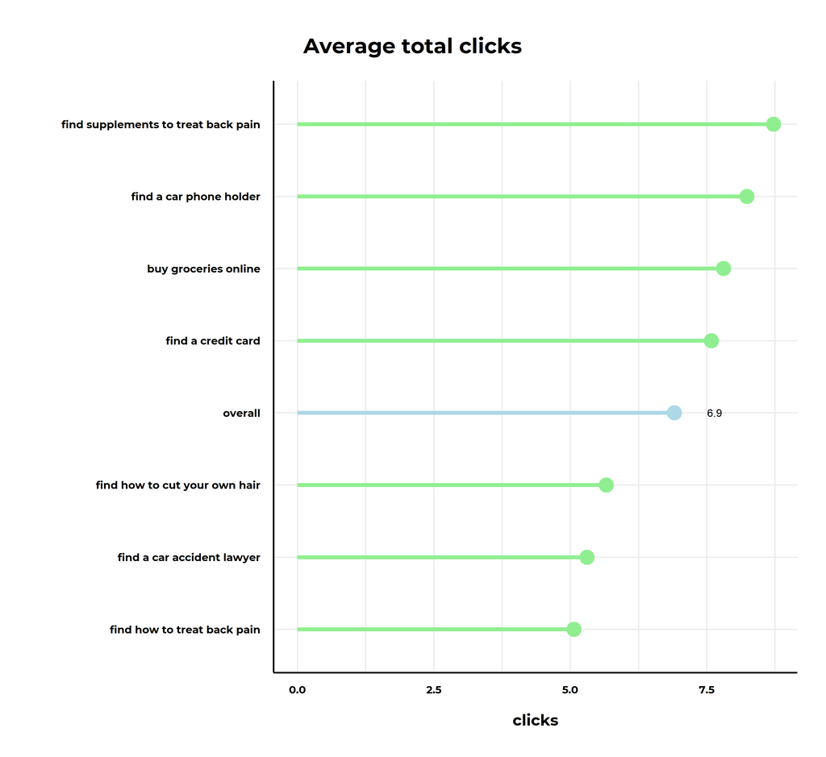

# 16. Relationships between variables

We observe some important correlations between some variables of our study. In particular the number of modified queries, the number of bounces, and the number of seconds to complete a search show correlations from 0.7 to 0.9.

This may indicate that users faced with a challenging Google search try different strategies.

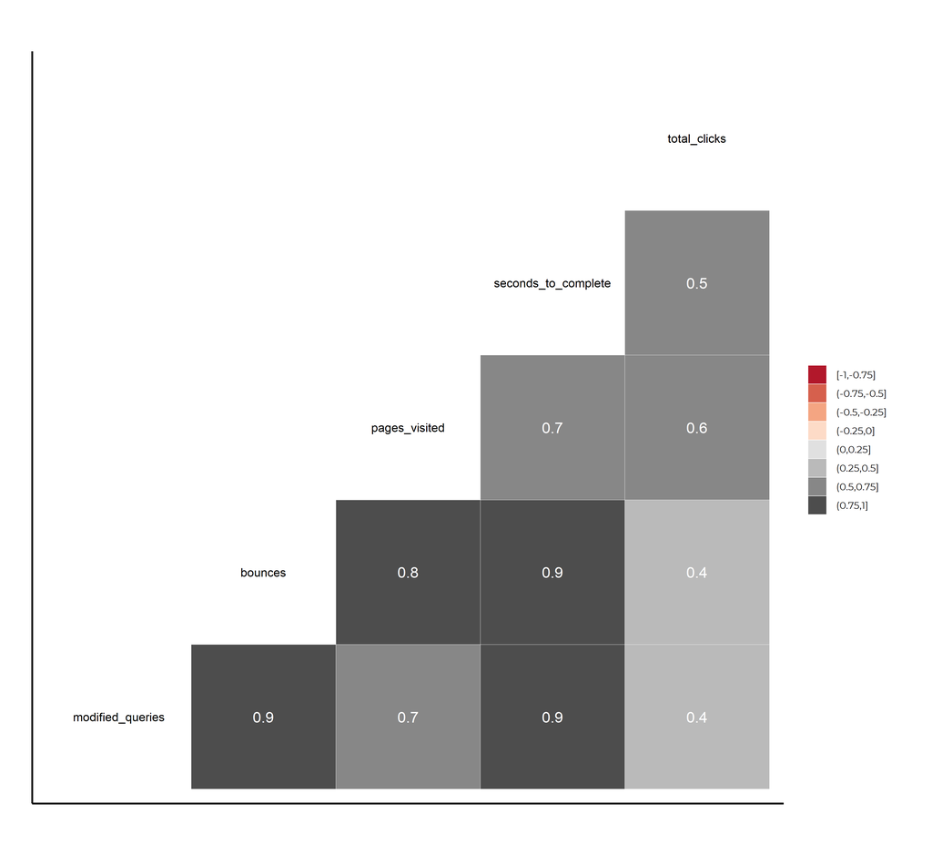